# DataReAnalysis

Julie Jung

November 9, 2017

### A Brief Introduction

Arboreal embryos of red-eyed treefrogs, *Agalychnis callidryas*, hatch prematurely to escape from egg predators, cued by vibrations in attacks. Young embryos modulate hatching based on multiple frequency and temporal properties of cues, reducing false alarms that unnecessarily expose them to risk in the water. Because the cost of false alarms decreases developmentally we hypothesized that, if sampling costs are high or stimuli ambiguous, older embryos would accept more false alarms.

### Methods, again briefly

We assessed changes in sensitivity to sampling costs using vibration playbacks at two developmental stages. We designed sets of 3 stimuli, based on prior results with younger embryos, so one elicited high hatching and two elicited similarly low hatching, but sampling costs differed between low-hatching stimuli.

### File logistics

The original paper and full dataset used are uploaded onto the repository in pdf and csv form, respectively. I will replicate all analyses included in the paper.

First, we will clear the environment and set our working directory:

```r
rm(list=ls()) #clear environment
setwd('/Users/juliejung/Documents/GitHub/AN 597/data-reanalysis-assignment') #set working directory
```

### User Defined Functions

Here we’ll define some functions that will help us later:

```r
#####################################################################
#########                f u n c t i o n s          #################
#####################################################################
```

The following function will give us the mode:

```r
# gives mode
Mode <- function(x) {
  ux <- unique(x)
  ux[which.max(tabulate(match(x, ux)))]
}
```

The following function will give us the count, mean, standard deviation, standard error of the mean, and confidence interval (default 95%). Details are in annotations within script.

Important Variables: - data: a data frame. - measurevar: the name of a column that contains the variable to be summarized - groupvars: a vector containing names of columns that contain grouping variables - na.rm: a boolean that indicates whether to ignore NA’s - conf.interval: the percent range of the confidence interval (default is 95%)

```r
summarySE <- function(data=NULL, measurevar, groupvars=NULL, na.rm=FALSE,
                      conf.interval=.95, .drop=TRUE) {
  library(plyr)
  # New version of length which can handle NA's: if na.rm==T, don't count them
  length2 <- function (x, na.rm=FALSE) {
    if (na.rm) sum(!is.na(x))
    else       length(x)
  }
  # This does the summary. For each group's data frame, return a vector with
  # N, mean, and sd
  datac <- ddply(data, groupvars, .drop=.drop,
                 .fun = function(xx, col) {
                   c(N    = length2(xx[[col]], na.rm=na.rm),
                     mean = mean   (xx[[col]], na.rm=na.rm),
                     sd   = sd     (xx[[col]], na.rm=na.rm)
                   )
                 },
                 measurevar
  )
  # Rename the "mean" column
  datac <- rename(datac, c("mean" = measurevar))
  datac$se <- datac$sd / sqrt(datac$N)  # Calculate standard error of the mean
  # Confidence interval multiplier for standard error
  # Calculate t-statistic for confidence interval:
  # e.g., if conf.interval is .95, use .975 (above/below), and use df=N-1
  ciMult <- qt(conf.interval/2 + .5, datac$N-1)
  datac$ci <- datac$se * ciMult
  return(datac)
}
```

### Preparation: Load packages

Here, we load packages that we’ll need later on in the code.

```r
library(curl)
```

```r
#library(xlsx)
library(sciplot)
library(ggplot2)
library(MASS)
library(multcomp)
library(AICcmodavg)
library(car)
```

### Preparation: read in data

Next, we want to read in the relevant datafile (from the data-reanalysis-assignment repo) and show a few lines of raw data in your output (e.g., using head()).

```r
f <- curl("https://raw.githubusercontent.com/jamjulie/data-reanalysis-assignment/master/WarkentinJungRuedaMcDaniel-DataForDeposit.csv")
data <- read.csv(f, header = TRUE, sep = ",", stringsAsFactors = TRUE)
head(data)
```

```
##       Date Age.d. Set TestOrder STIMULUS SetupTime.h.  Tray
## 1 20151013    5.2   1         1       LS         3.02 390-2
## 2 20151013    5.2   1         2       LF         3.35   390
## 3 20151013    5.2   1         3       HF         3.75   370
## 4 20151013    5.2   2         4       HF         4.08 388-2
## 5 20151013    5.2   2         5       LS         4.45   388
## 6 20151013    5.2   2         6       LF         4.82 383-2
##   AlreadyHatchedorRuptured HatchedinSetup LessDeveloped TestEggs
## 1                        1              1             0       13
## 2                        3              0             0       12
## 3                        2              0             0       13
## 4                        1              2             0       12
## 5                        0              0             0       15
## 6                        3              0             1       11
##   FirstHatch.s. FirstHatch.s.600 CycleLength.s. FirstHatch.cycles.
```

[output cut: 20 more lines]

### Results

The following results follow the order of presented results in the paper (pdf in repo).

First, we will check there are at least 8 eggs per tray.

```r
min(data$TestEggs, na.rm=T)
```

```
## [1] 8
```

Now let’s look at the structure of our data, and make sure the variables are defined as we want them to be defined.

```r
str(data)
```

```
## 'data.frame':    81 obs. of  24 variables:
##  $ Date                    : int  20151013 20151013 20151013 20151013 20151013 20151013 20151013 20151013 20151013 20151013 ...
##  $ Age.d.                  : num  5.2 5.2 5.2 5.2 5.2 5.2 5.2 5.2 5.2 5.2 ...
##  $ Set                     : int  1 1 1 2 2 2 3 3 3 4 ...
##  $ TestOrder               : int  1 2 3 4 5 6 7 8 9 10 ...
##  $ STIMULUS                : Factor w/ 3 levels "HF","LF","LS": 3 2 1 1 3 2 3 1 2 1 ...
##  $ SetupTime.h.            : num  3.02 3.35 3.75 4.08 4.45 4.82 5.27 5.77 6.08 6.52 ...
##  $ Tray                    : Factor w/ 81 levels "370","371-2",..: 27 26 1 24 23 18 17 25 22 19 ...
##  $ AlreadyHatchedorRuptured: int  1 3 2 1 0 3 1 1 0 0 ...
##  $ HatchedinSetup          : int  1 0 0 2 0 0 0 0 0 1 ...
##  $ LessDeveloped           : int  0 0 0 0 0 1 0 0 0 0 ...
##  $ TestEggs                : int  13 12 13 12 15 11 14 14 15 14 ...
##  $ FirstHatch.s.           : int  90 79 NA NA 67 24 NA 58 34 NA ...
##  $ FirstHatch.s.600        : int  90 79 600 600 67 24 600 58 34 600 ...
##  $ CycleLength.s.          : int  17 2 2 2 17 2 17 2 2 2 ...
##  $ FirstHatch.cycles.      : num  5.29 39.5 NA NA 3.94 ...
##  $ FirstHatch.cycles.600   : num  5.29 39.5 300 300 3.94 ...
##  $ X5minHatch              : int  2 2 0 0 3 1 0 2 5 0 ...
##  $ X10minHatch             : int  2 2 0 0 3 2 1 2 5 0 ...
##  $ ProportionHatched       : num  0.154 0.167 0 0 0.2 0.182 0.071 0.143 0.333 0 ...
##  $ GutCoilStage            : int  NA NA NA 0 0 1 1 0 0 1 ...
##  $ T1length                : num  10.8 10.5 10.5 10.2 10.7 ...
##  $ T2length                : num  8.12 10.7 10.53 10.77 10.35 ...
##  $ T3length                : Factor w/ 80 levels "10.323","10.368",..: 21 22 16 7 41 1 10 13 2 20 ...
##  $ MeanLength              : num  10 10.8 10.7 10.6 10.8 ...
```

```r
data$GutCoilStage<-as.numeric(as.character(data$GutCoilStage))
data$T3length<-as.numeric(as.character(data$T3length))
data$ProportionHatched<-as.numeric(as.character(data$ProportionHatched))
data$STIMULUS<-as.factor(data$STIMULUS)
data$FirstHatch.s. <-as.numeric(as.character(data$FirstHatch.s. ))
data$FirstHatch.cycles. <-as.numeric(as.character(data$FirstHatch.cycles. ))
```

Here let’s subset the data into 2 age groups: younger and older.

```r
younger<-subset(data, Age.d.==5.2, na.rm=T)
older<-subset(data, Age.d.==5.7, na.rm=T)
```

Since the paper reports the mode of stages for each age category, let’s find that:

```r
Mode(younger$GutCoilStage)
```

```
## [1] 1
```

```r
Mode(older$GutCoilStage)
```

```
## [1] 3
```

Here we’ll create a table summary of statistics for hatching rates (in proportion hatched) for each age category, grouped by stimulus treatment.

“summarySE”" is a user defined function, which you’ll find above in the functions section.

```r
younger_errorstats_g8 <- summarySE(younger, measurevar="ProportionHatched", groupvars="STIMULUS")
younger_errorstats_g8$AgeGroup<-"younger"

older_errorstats_g8 <- summarySE(older, measurevar="ProportionHatched", groupvars="STIMULUS")
older_errorstats_g8$AgeGroup<-"older"
```

Should we use parametric or non-parametric tests?

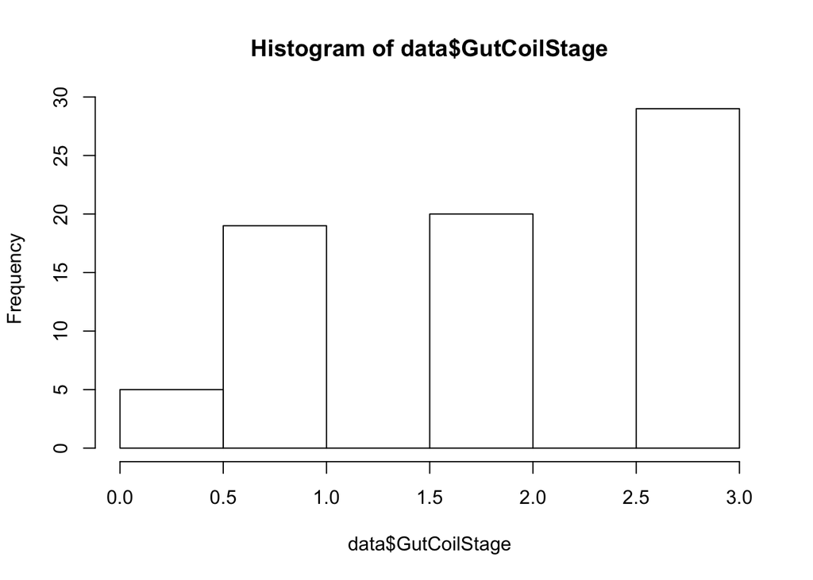

```r
hist(data$GutCoilStage) #non parametric
```

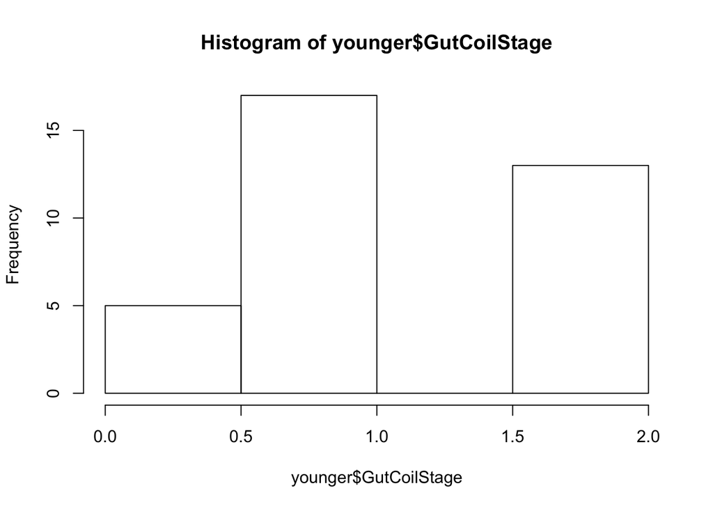

```r
hist(younger$GutCoilStage)
```

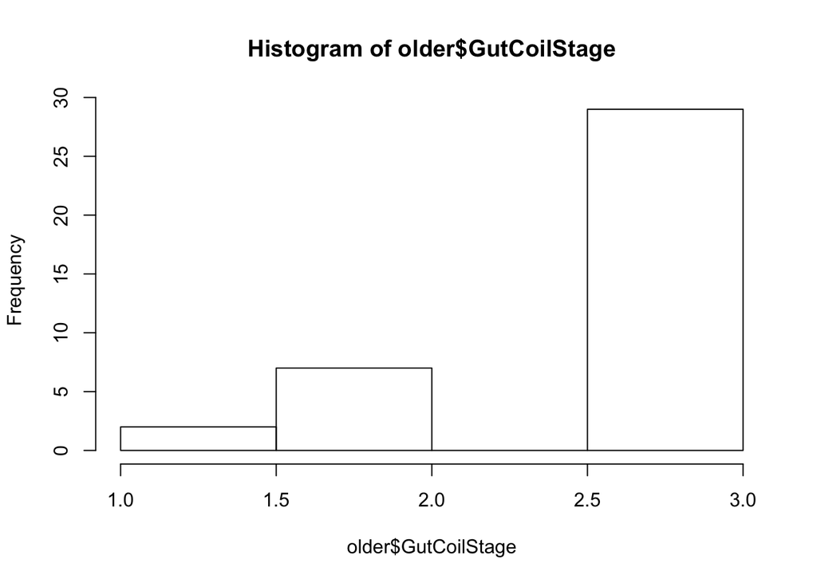

```r
hist(older$GutCoilStage)
```

We’ll use mann-whitney-wilcoxon test because our 2 data samples (younger and older) are independent/come from distinct populations, so the samples do not affect each other.

Also because our data are non-parametric.

```r
wtest<-wilcox.test(data$GutCoilStage~data$Age.d., mu = 0, alt="two.sided", paired = F, conf.int=T, conf.level=0.95)
qnorm(wtest$p.value) #z-value to report
```

```
## [1] -6.606223
```

```r
wtest
```

```
##
##  Wilcoxon rank sum test with continuity correction
##
## data:  data$GutCoilStage by data$Age.d.
## W = 88.5, p-value = 1.971e-11
## alternative hypothesis: true location shift is not equal to 0
## 95 percent confidence interval:
##  -1.999996 -1.000003
## sample estimates:
## difference in location
##              -1.999985
```

Moving right along, here we’ll calculation the total lengths (mean and se) of hatchlings in each age group.

```r
mean(younger$MeanLength)
```

```
## [1] 11.06536
```

```r
mean(older$MeanLength)
```

```
## [1] 11.64307
```

```r
se(younger$MeanLength)
```

```
## [1] 0.07123206
```

```r
se(older$MeanLength)
```

```
## [1] 0.0546835
```

Since the data are normal and we get equal variances, we’ll perform a t-test.

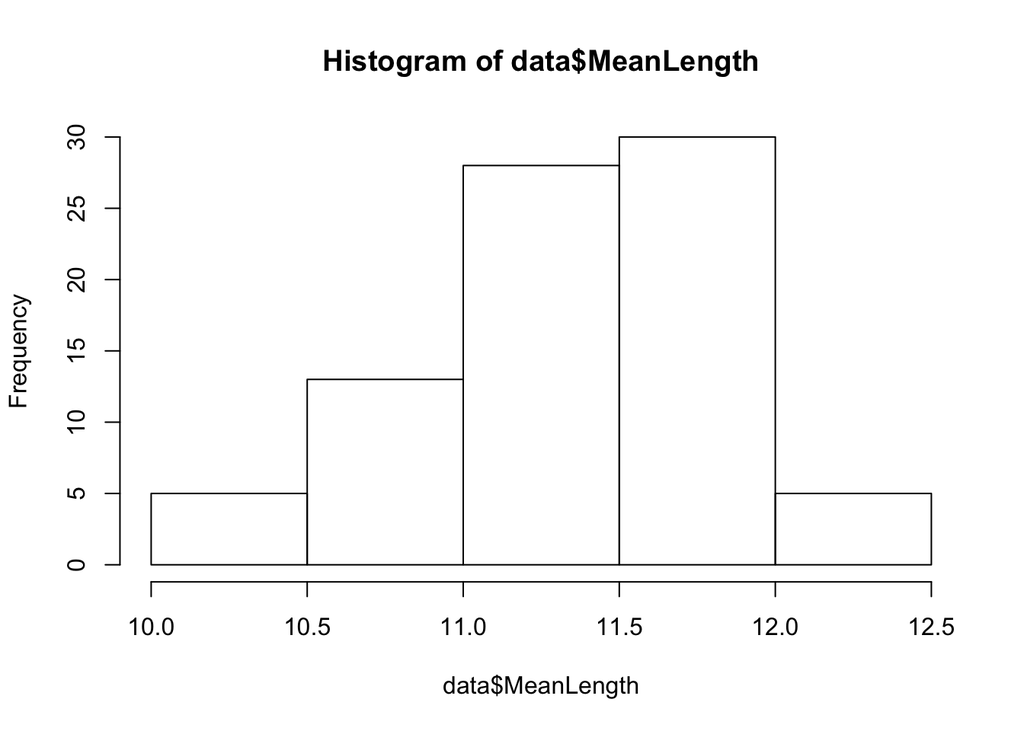

```r
hist(data$MeanLength)#normal
```

```r
var.test(younger$MeanLength, older$MeanLength) # equal variances
```

```
##
##  F test to compare two variances
##
## data:  younger$MeanLength and older$MeanLength
## F = 1.5756, num df = 38, denom df = 41, p-value = 0.1554
## alternative hypothesis: true ratio of variances is not equal to 1
## 95 percent confidence interval:
##  0.8396433 2.9795488
## sample estimates:
## ratio of variances
##           1.575628
```

```r
t.test(younger$MeanLength, older$MeanLength, alternative=c("two.sided"), paired=FALSE, var.equal=TRUE, conf.level=0.95)
```

```
##
##  Two Sample t-test
##
## data:  younger$MeanLength and older$MeanLength
## t = -6.4874, df = 79, p-value = 7.01e-09
## alternative hypothesis: true difference in means is not equal to 0
## 95 percent confidence interval:
##  -0.7549655 -0.4004594
## sample estimates:
## mean of x mean of y
##  11.06536  11.64307
```

We want to calculate some means and ses for spontaneous hatching before the test period.

```r
mean(younger$AlreadyHatchedorRuptured)
```

```
## [1] 0.5128205
```

```r
se(younger$AlreadyHatchedorRuptured)
```

```
## [1] 0.1317985
```

```r
mean(older$AlreadyHatchedorRuptured)
```

```
## [1] 0.9047619
```

```r
se(older$AlreadyHatchedorRuptured)
```

```
## [1] 0.1219733
```

Since the data are non-parametric, we’ll perform a mann-whitney test:

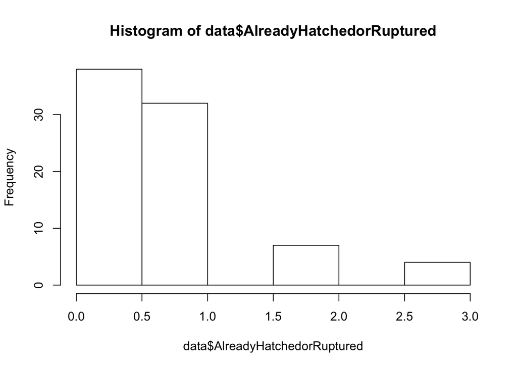

```r
hist(data$AlreadyHatchedorRuptured)#non-parametric, mann-whitney
```

```r
wtest<-wilcox.test(data$AlreadyHatchedorRuptured~data$Age.d., mu = 0, alt="two.sided", paired = F, conf.int=T, conf.level=0.95)
qnorm(wtest$p.value) #z-value to report
```

```
## [1] -2.439028
```

```r
wtest
```

```
##
##  Wilcoxon rank sum test with continuity correction
##
## data:  data$AlreadyHatchedorRuptured by data$Age.d.
## W = 559.5, p-value = 0.007363
## alternative hypothesis: true location shift is not equal to 0
## 95 percent confidence interval:
##  -9.999772e-01 -6.210509e-05
## sample estimates:
## difference in location
##          -2.881878e-05
```

We want to calculate some means and ses for the number of individuals that hatched before the test period.

```r
# hatching from set up
mean(younger$HatchedinSetup)
```

```
## [1] 0.8974359
```

```r
se(younger$HatchedinSetup)
```

```
## [1] 0.2317418
```

```r
mean(older$HatchedinSetup)
```

```
## [1] 2.452381
```

```r
se(older$HatchedinSetup)
```

```
## [1] 0.2974971
```

Since the data are non-parametric, we’ll perform a mann-whitney test:

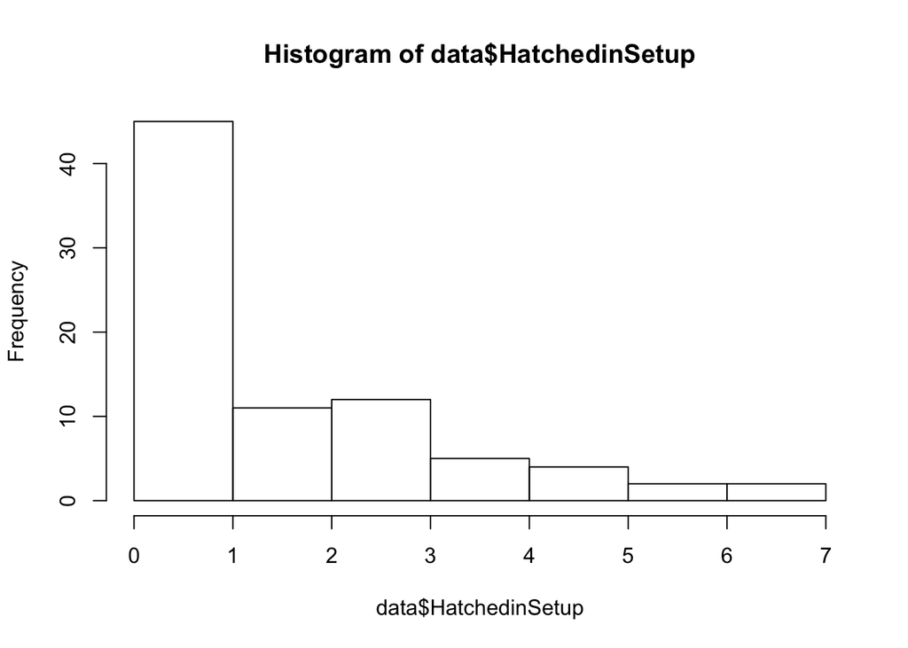

```r
hist(data$HatchedinSetup)#non-parametric, mann-whitney
```

```r
wtest<-wilcox.test(data$HatchedinSetup~data$Age.d., mu = 0, alt="two.sided", paired = F, conf.int=T, conf.level=0.95)
qnorm(wtest$p.value) #z-value to report
```

```
## [1] -3.886517
```

```r
wtest
```

```
##
##  Wilcoxon rank sum test with continuity correction
##
## data:  data$HatchedinSetup by data$Age.d.
## W = 404.5, p-value = 5.085e-05
## alternative hypothesis: true location shift is not equal to 0
## 95 percent confidence interval:
##  -2.0000029 -0.9999489
## sample estimates:
## difference in location
##              -1.000005
```

We want to calculate some means and ses for the number of test eggs per tray in older vs. younger.

```r
#smaller number of test eggs per tray in older than younger
mean(younger$TestEggs)
```

```
## [1] 13.46154
```

```r
se(younger$TestEggs)
```

```
## [1] 0.2404622
```

```r
mean(older$TestEggs)
```

```
## [1] 11.45238
```

```r
se(older$TestEggs)
```

```
## [1] 0.3089873
```

```r
min(younger$TestEggs)
```

```
## [1] 8
```

```r
max(younger$TestEggs)
```

```
## [1] 15
```

```r
min(older$TestEggs)
```

```
## [1] 8
```

```r
max(older$TestEggs)
```

```
## [1] 15
```

Since the data are non-parametric, we’ll perform a mann-whitney test:

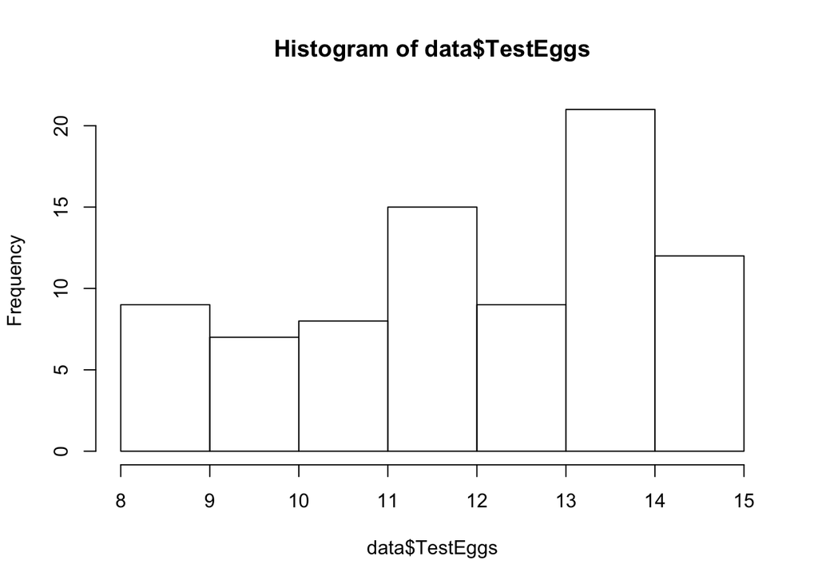

```r
hist(data$TestEggs)#non-parametric, mann-whitney
```

```r
wtest<-wilcox.test(data$TestEggs~data$Age.d., mu = 0, alt="two.sided", paired = F, conf.int=T, conf.level=0.95)
qnorm(wtest$p.value) #z-value to report
```

```
## [1] -4.361872
```

```r
wtest
```

```
##
##  Wilcoxon rank sum test with continuity correction
##
## data:  data$TestEggs by data$Age.d.
## W = 1289.5, p-value = 6.448e-06
## alternative hypothesis: true location shift is not equal to 0
## 95 percent confidence interval:
##  1.000044 2.999979
## sample estimates:
## difference in location
##               2.000011
```

Next, we want to know whether age, stimulus, and/or their interaction affected the hatching response of embryos in playbacks

We’ll do this by performing a binomial GLM:

```r
#binomial glm
glm1<-glm(cbind(X10minHatch,TestEggs)~Age.d., family=binomial(logit), data=data)
glm2<-glm(cbind(X10minHatch,TestEggs)~STIMULUS, family=binomial(logit), data=data)
glm3<-glm(cbind(X10minHatch,TestEggs)~Age.d.+STIMULUS, family=binomial(logit), data=data)
glm4<-glm(cbind(X10minHatch,TestEggs)~Age.d.*STIMULUS, family=binomial(logit), data=data)

glms<-list(glm1, glm2, glm3, glm4)
aictab(glms)
```

```
##
## Model selection based on AICc :
##
##      K   AICc Delta_AICc AICcWt Cum.Wt      LL
## Mod4 6 329.47       0.00   0.97   0.97 -158.17
## Mod3 4 336.80       7.33   0.03   1.00 -164.14
## Mod1 2 390.29      60.82   0.00   1.00 -193.07
## Mod2 3 394.16      64.69   0.00   1.00 -193.93
```

```r
Anova(glm4)
```

```
## Analysis of Deviance Table (Type II tests)
##
## Response: cbind(X10minHatch, TestEggs)
##                 LR Chisq Df Pr(>Chisq)
## Age.d.            59.578  1  1.175e-14 ***
## STIMULUS          57.863  2  2.724e-13 ***
## Age.d.:STIMULUS   11.934  2   0.002562 **
## ---
## Signif. codes:  0 '***' 0.001 '**' 0.01 '*' 0.05 '.' 0.1 ' ' 1
```

This is the plot for our proportion hatched data (Figure 6 in paper)

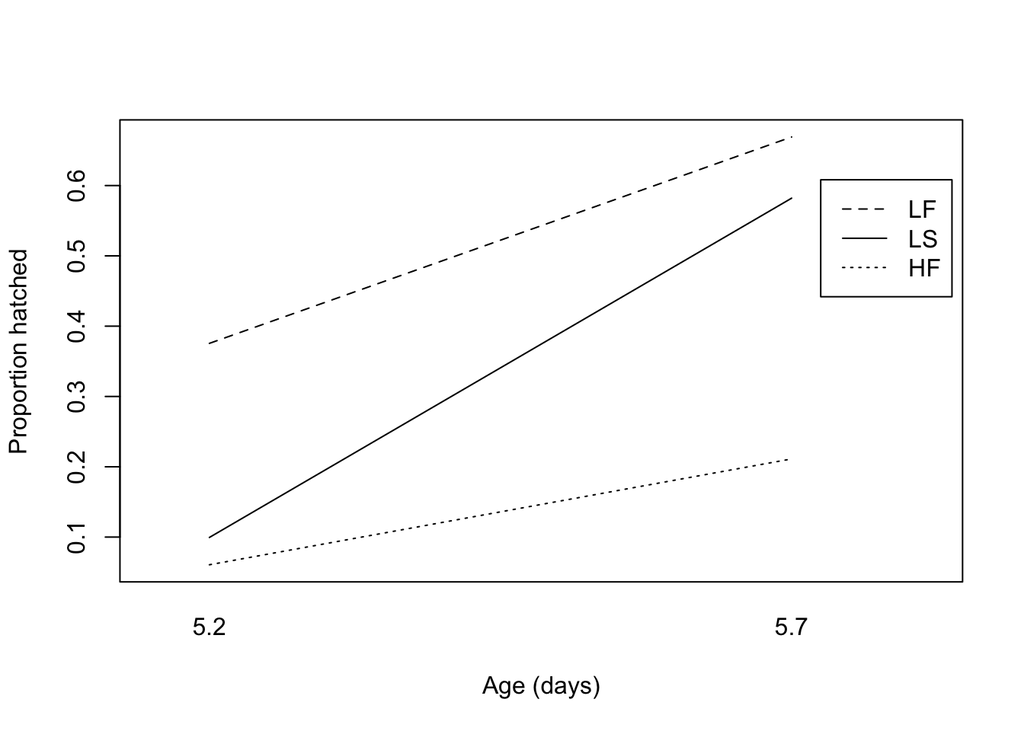

```r
interaction.plot(data$Age.d., data$STIMULUS, data$ProportionHatched,
                 leg.bty="0", pch=c(18,24),
                 ylab="Proportion hatched",
                 xlab="Age (days)",
                 trace.label="")
```

ALTERNATIVELY, we can use ggplot to create a much prettier plot, with standard errors. Note that ideally the order of younger and older would be switched, but the data presented are the same as presented in the original paper.

If I wanted to, I could switch this order by following the steps through this [link](https://stackoverflow.com/questions/3253641/change-the-order-of-a-discrete-x-scale):

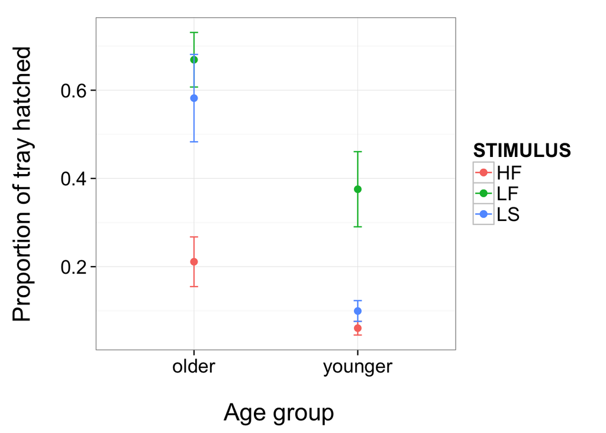

```r
ggplot(data, aes(x=as.factor(AgeGroup), y=ProportionHatched, colour=STIMULUS)) +
  geom_point(data=younger_errorstats_g8 , size=3) +
  geom_errorbar(data=younger_errorstats_g8, aes(ymin=ProportionHatched-se, ymax=ProportionHatched+se), width=0.05)+
  geom_point(data=older_errorstats_g8, size=3) +
  geom_line(data=older_errorstats_g8)+
  geom_errorbar(data=older_errorstats_g8, aes(ymin=ProportionHatched-se, ymax=ProportionHatched+se), width=0.05)+
  theme_bw(20)+
  ylab("Proportion of tray hatched\n")+
  xlab("\n Age group")
```

Moving on: Here we perform separate binomial GLMs at each age, with grouped categories of treatment stimuli.

```r
#binomial glm for YOUNGER
glm2<-glm(cbind(X10minHatch,TestEggs)~STIMULUS, family=binomial(logit), data=younger)
Anova(glm2)
```

```
## Analysis of Deviance Table (Type II tests)
##
## Response: cbind(X10minHatch, TestEggs)
##          LR Chisq Df Pr(>Chisq)
## STIMULUS   40.133  2  1.929e-09 ***
## ---
## Signif. codes:  0 '***' 0.001 '**' 0.01 '*' 0.05 '.' 0.1 ' ' 1
```

```r
#binomial glm for OLDER
glm2<-glm(cbind(X10minHatch,TestEggs)~STIMULUS, family=binomial(logit), data=older)
Anova(glm2)
```

```
## Analysis of Deviance Table (Type II tests)
##
## Response: cbind(X10minHatch, TestEggs)
##          LR Chisq Df Pr(>Chisq)
## STIMULUS   29.664  2  3.618e-07 ***
## ---
## Signif. codes:  0 '***' 0.001 '**' 0.01 '*' 0.05 '.' 0.1 ' ' 1
```

Latency Analysis:

Because risk in predator attacks probably accrues as a function of time, but information from temporal properties accrues as a function of cycles we conducted analyses of latency measured both in time (seconds) and in cycles (dividing time by the cycle length of the stimulus).

```r
min(data$FirstHatch.s., na.rm=T)
```

```
## [1] 9
```

```r
max(data$FirstHatch.s., na.rm=T)
```

```
## [1] 420
```

```r
data$FirstHatch.cycles.
```

```
##  [1]   5.2941176  39.5000000          NA          NA   3.9411765
##  [6]  12.0000000          NA  29.0000000  17.0000000          NA
## [11]  12.3529412  29.5000000          NA   9.5000000  80.0000000
## [16]  61.5000000  12.5000000   1.5882353          NA 210.0000000
## [21]  60.0000000 125.5000000  12.0000000   3.7647059  13.0000000
## [26]  13.9411765  22.5000000          NA          NA          NA
## [31]          NA          NA          NA   7.2941176   5.5000000
## [36] 115.5000000   6.5000000  22.5000000   4.0588235  17.0000000
## [41]   0.8235294  12.5000000  47.5000000   6.0000000   1.8823529
## [46]   2.6470588  13.5000000  15.0000000  18.0000000   7.5000000
## [51]   1.7058824          NA          NA  10.5000000          NA
## [56]   4.1176471   8.5000000   2.0000000          NA  11.5000000
## [61]   8.0000000          NA   1.4705882   0.7647059  10.0000000
## [66]   6.5000000  12.0000000   1.3529412  10.0000000   5.5000000
## [71]   0.5294118  12.5000000   2.1176471   9.0000000  19.5000000
## [76]  13.5000000   8.0000000   4.4705882   1.0588235  13.0000000
## [81]   5.5000000
```

Are our data parametric?

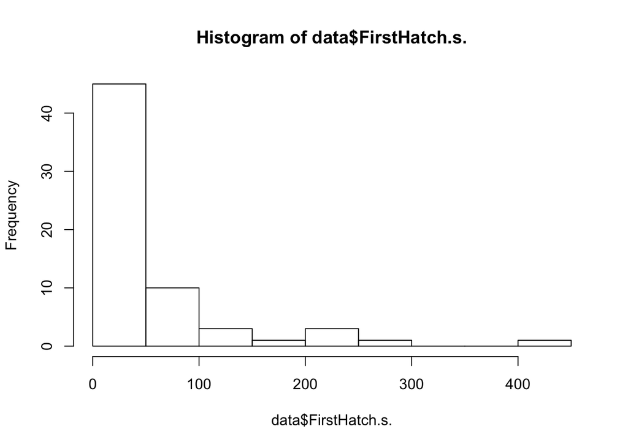

```r
hist(data$FirstHatch.s.) #nonparametric
```

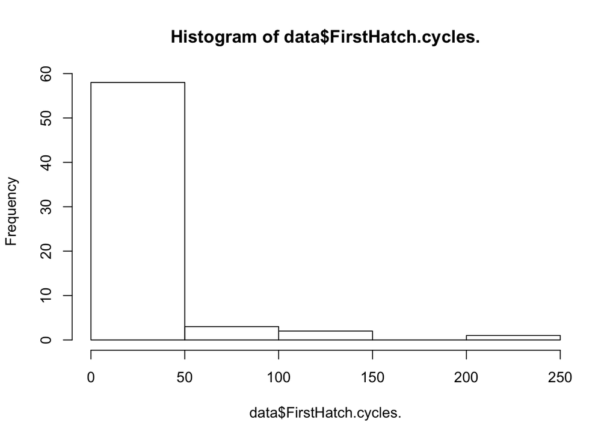

```r
hist(data$FirstHatch.cycles.) #nonparametric
```

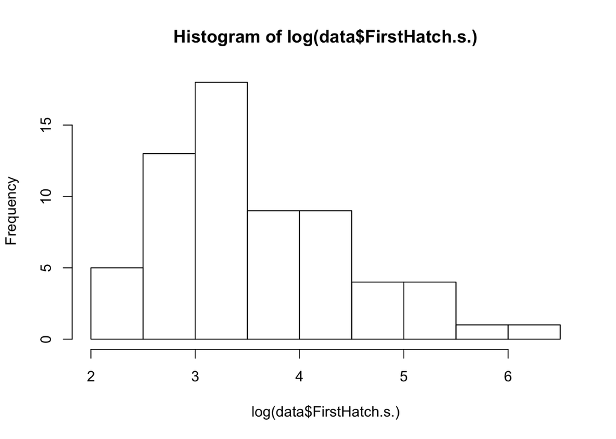

```r
hist(log(data$FirstHatch.s.)) #parametric!
```

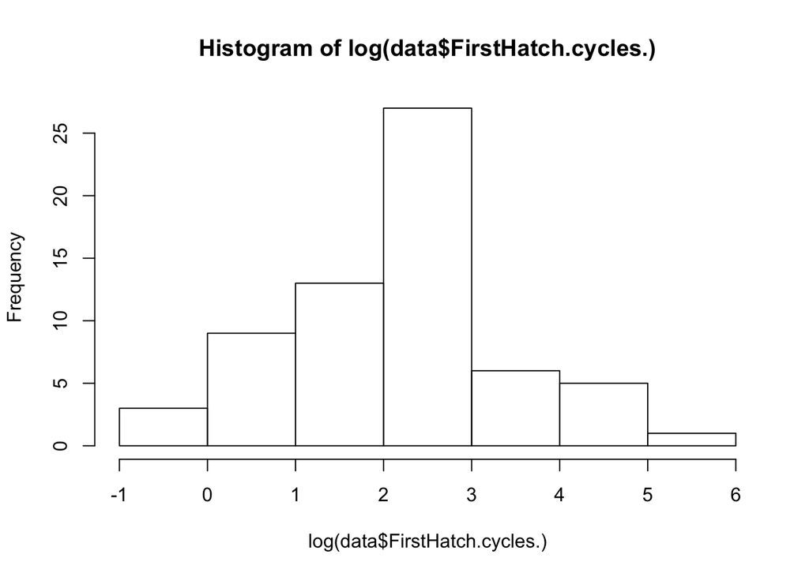

```r
hist(log(data$FirstHatch.cycles.)) #parametric!
```

```r
# IN SECONDS, Anova
aov1 <- aov(FirstHatch.s. ~ Age.d.*STIMULUS, data=data)
summary(aov1)
```

```
##                 Df Sum Sq Mean Sq F value   Pr(>F)
## Age.d.           1  77870   77870  25.158 5.31e-06 ***
## STIMULUS         2  45922   22961   7.418  0.00135 **
## Age.d.:STIMULUS  2  32665   16332   5.277  0.00785 **
## Residuals       58 179525    3095
## ---
## Signif. codes:  0 '***' 0.001 '**' 0.01 '*' 0.05 '.' 0.1 ' ' 1
## 17 observations deleted due to missingness
```

```r
# IN CYCLES, Anova
aov2 <- aov(FirstHatch.cycles. ~ Age.d.*STIMULUS, data=data)
summary(aov2)
```

```
##                 Df Sum Sq Mean Sq F value   Pr(>F)
## Age.d.           1  10440   10440  17.838 8.59e-05 ***
## STIMULUS         2  18059    9029  15.429 4.24e-06 ***
## Age.d.:STIMULUS  2  10953    5476   9.358    3e-04 ***
## Residuals       58  33943     585
## ---
## Signif. codes:  0 '***' 0.001 '**' 0.01 '*' 0.05 '.' 0.1 ' ' 1
## 17 observations deleted due to missingness
```

Alternatively, we can use GLMs:

```r
# IN SECONDS, GLM METHOD
glm1<-glm(FirstHatch.s.~Age.d., family=gaussian(link = "identity"), data=data)
glm2<-glm(FirstHatch.s.~STIMULUS, family=gaussian(link = "identity"), data=data)
glm3<-glm(FirstHatch.s.~Age.d.+STIMULUS, family=gaussian(link = "identity"), data=data)
glm4<-glm(FirstHatch.s.~Age.d.*STIMULUS, family=gaussian(link = "identity"), data=data)

glms<-list(glm1, glm2, glm3, glm4)
aictab(glms)
```

```
##
## Model selection based on AICc :
##
##      K   AICc Delta_AICc AICcWt Cum.Wt      LL
## Mod4 7 705.73       0.00   0.95   0.95 -344.87
## Mod3 5 711.47       5.73   0.05   1.00 -350.22
## Mod1 3 719.37      13.64   0.00   1.00 -356.48
## Mod2 4 729.28      23.55   0.00   1.00 -360.30
```

```r
Anova(glm4)
```

```
## Analysis of Deviance Table (Type II tests)
##
## Response: FirstHatch.s.
##                 LR Chisq Df Pr(>Chisq)
## Age.d.            25.396  1  4.669e-07 ***
## STIMULUS          14.836  2  0.0006002 ***
## Age.d.:STIMULUS   10.553  2  0.0051100 **
## ---
## Signif. codes:  0 '***' 0.001 '**' 0.01 '*' 0.05 '.' 0.1 ' ' 1
```

Here we plot the latencies for the first embryo in each tray to hatch:

In order to do this, we’ll get the SEs using our summarySE function.

```r
LtoH_younger_errorstats_g8 <- summarySE(younger, measurevar="FirstHatch.s.", groupvars="STIMULUS", na.rm=TRUE)
LtoH_younger_errorstats_g8$AgeGroup<-"younger"

LtoH_older_errorstats_g8 <- summarySE(older, measurevar="FirstHatch.s.", groupvars="STIMULUS", na.rm=TRUE)
LtoH_older_errorstats_g8$AgeGroup<-"older"
```

Now we can make the plot!

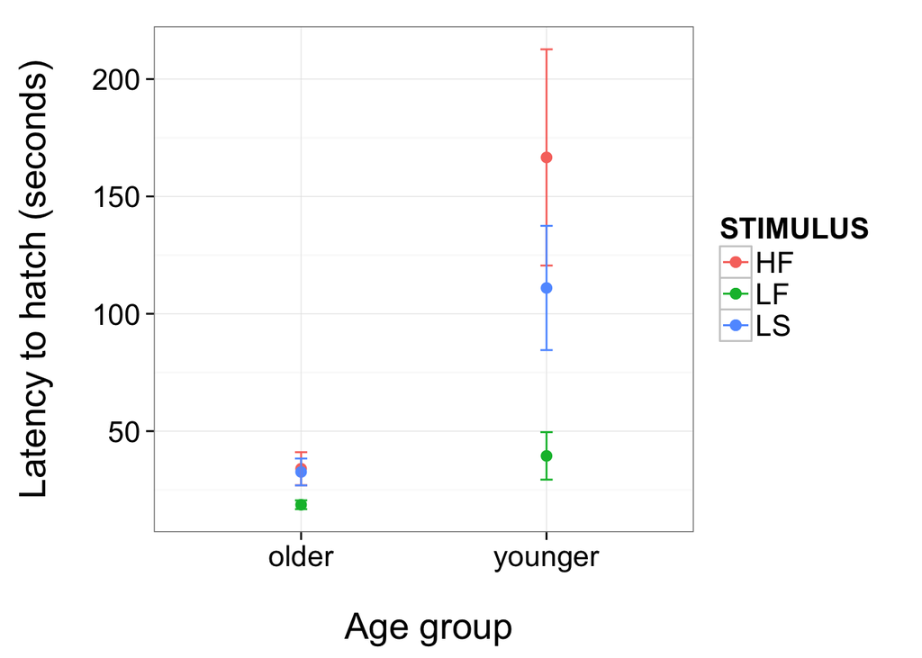

```r
ggplot(data, aes(x=as.factor(AgeGroup), y=FirstHatch.s., colour=STIMULUS)) +
  geom_point(data=LtoH_younger_errorstats_g8 , size=3) +
  geom_errorbar(data=LtoH_younger_errorstats_g8, aes(ymin=FirstHatch.s.-se, ymax=FirstHatch.s.+se), width=0.05)+
  geom_point(data=LtoH_older_errorstats_g8, size=3) +
  geom_errorbar(data=LtoH_older_errorstats_g8, aes(ymin=FirstHatch.s.-se, ymax=FirstHatch.s.+se), width=0.05)+
  theme_bw(20)+
  ylab("Latency to hatch (seconds)\n")+
  xlab("\n Age group")
```

Recall that because risk in predator attacks probably accrues as a function of time, but information from temporal properties accrues as a function of cycles, we conducted analyses of latency measured both in time (seconds) and in cycles (dividing time by the cycle length of the stimulus).

```r
## IN CYCLES, GLM METHOD

glm1<-glm(FirstHatch.cycles.~Age.d., family=gaussian(link = "identity"), data=data)
glm2<-glm(FirstHatch.cycles.~STIMULUS, family=gaussian(link = "identity"), data=data)
glm3<-glm(FirstHatch.cycles.~Age.d.+STIMULUS, family=gaussian(link = "identity"), data=data)
glm4<-glm(FirstHatch.cycles.~Age.d.*STIMULUS, family=gaussian(link = "identity"), data=data)

glms<-list(glm1, glm2, glm3, glm4)
aictab(glms)
```

```
##
## Model selection based on AICc :
##
##      K   AICc Delta_AICc AICcWt Cum.Wt      LL
## Mod4 7 599.13       0.00      1      1 -291.57
## Mod3 5 612.07      12.93      0      1 -300.52
## Mod2 4 621.83      22.70      0      1 -306.58
## Mod1 3 629.07      29.93      0      1 -311.33
```

```r
Anova(glm4)
```

```
## Analysis of Deviance Table (Type II tests)
##
## Response: FirstHatch.cycles.
##                 LR Chisq Df Pr(>Chisq)
## Age.d.            15.999  1  6.337e-05 ***
## STIMULUS          30.858  2  1.992e-07 ***
## Age.d.:STIMULUS   18.715  2  8.630e-05 ***
## ---
## Signif. codes:  0 '***' 0.001 '**' 0.01 '*' 0.05 '.' 0.1 ' ' 1
```

The shortest latency times were for the LF stimulus (younger: 39.5 ± 10.1 s; older 18.6 ± 1.9 s), while latencies for the LS stimulus included the fewest cycles of the vibration pattern (younger: 6.5 ± 1.6; older: 1.9 ± 0.3 cycles).

```r
HF<-subset(data, STIMULUS=="HF", na.rm=T)
LF<-subset(data, STIMULUS=="LF", na.rm=T)
LS<-subset(data, STIMULUS=="LS", na.rm=T)

HFyounger<-subset(HF, Age.d.==5.2, na.rm=T)
HFolder<-subset(HF, Age.d.==5.7, na.rm=T)
LFyounger<-subset(LF, Age.d.==5.2, na.rm=T)
LFolder<-subset(LF, Age.d.==5.7, na.rm=T)
LSyounger<-subset(LS, Age.d.==5.2, na.rm=T)
LSolder<-subset(LS, Age.d.==5.7, na.rm=T)

mean(LFyounger$FirstHatch.s., na.rm=T)
```

```
## [1] 39.45455
```

```r
se(LFyounger$FirstHatch.s., na.rm=T)
```

```
## [1] 10.11692
```

```r
mean(LFolder$FirstHatch.s., na.rm=T)
```

```
## [1] 18.64286
```

```r
se(LFolder$FirstHatch.s., na.rm=T)
```

```
## [1] 1.877007
```

```r
mean(LSyounger$FirstHatch.cycles., na.rm=T)
```

```
## [1] 6.529412
```

```r
se(LSyounger$FirstHatch.cycles., na.rm=T)
```

```
## [1] 1.557356
```

```r
mean(LSolder$FirstHatch.cycles., na.rm=T)
```

```
## [1] 1.918552
```

```r
se(LSolder$FirstHatch.cycles., na.rm=T)
```

```
## [1] 0.3367673
```

We conducted analyses of latency both on the subset of trays from which at least one individual hatched and also on the full dataset, assigning a latency of 600 s (i.e., the full playback plus post-playback observation period) to trays in which no embryos hatched.

```r
# IN SECONDS, Anova
aov1 <- aov(FirstHatch.s.600 ~ Age.d.*STIMULUS, data=data)
summary(aov1)
```

```
##                 Df  Sum Sq Mean Sq F value  Pr(>F)
## Age.d.           1  497562  497562  11.521 0.00110 **
## STIMULUS         2  501036  250518   5.801 0.00455 **
## Age.d.:STIMULUS  2   51388   25694   0.595 0.55418
## Residuals       75 3239146   43189
## ---
## Signif. codes:  0 '***' 0.001 '**' 0.01 '*' 0.05 '.' 0.1 ' ' 1
```

```r
# IN SECONDS, GLM METHOD
glm1<-glm(FirstHatch.s.600~Age.d., family=gaussian(link = "identity"), data=data)
glm2<-glm(FirstHatch.s.600~STIMULUS, family=gaussian(link = "identity"), data=data)
glm3<-glm(FirstHatch.s.600~Age.d.+STIMULUS, family=gaussian(link = "identity"), data=data)
glm4<-glm(FirstHatch.s.600~Age.d.*STIMULUS, family=gaussian(link = "identity"), data=data)

glms<-list(glm1, glm2, glm3, glm4)
aictab(glms)
```

```
##
## Model selection based on AICc :
##
##      K    AICc Delta_AICc AICcWt Cum.Wt      LL
## Mod3 5 1100.25       0.00   0.82   0.82 -544.72
## Mod4 7 1103.71       3.46   0.15   0.97 -544.09
## Mod1 3 1107.24       6.99   0.02   0.99 -550.46
## Mod2 4 1109.38       9.13   0.01   1.00 -550.43
```

```r
Anova(glm4)
```

```
## Analysis of Deviance Table (Type II tests)
##
## Response: FirstHatch.s.600
##                 LR Chisq Df Pr(>Chisq)
## Age.d.           11.5207  1  0.0006883 ***
## STIMULUS         11.6011  2  0.0030259 **
## Age.d.:STIMULUS   1.1899  2  0.5516027
## ---
## Signif. codes:  0 '***' 0.001 '**' 0.01 '*' 0.05 '.' 0.1 ' ' 1
```

Here we plot the latencies for the first embryo in each tray to hatch IN CYCLES:

In order to do this, we’ll get the SEs using our summarySE function.

```r
cycles_younger_errorstats_g8 <- summarySE(younger, measurevar="FirstHatch.cycles.", groupvars="STIMULUS", na.rm=TRUE)
cycles_younger_errorstats_g8$AgeGroup<-"younger"

cycles_older_errorstats_g8 <- summarySE(older, measurevar="FirstHatch.cycles.", groupvars="STIMULUS", na.rm=TRUE)
cycles_older_errorstats_g8$AgeGroup<-"older"
```

Now we can make the plot!

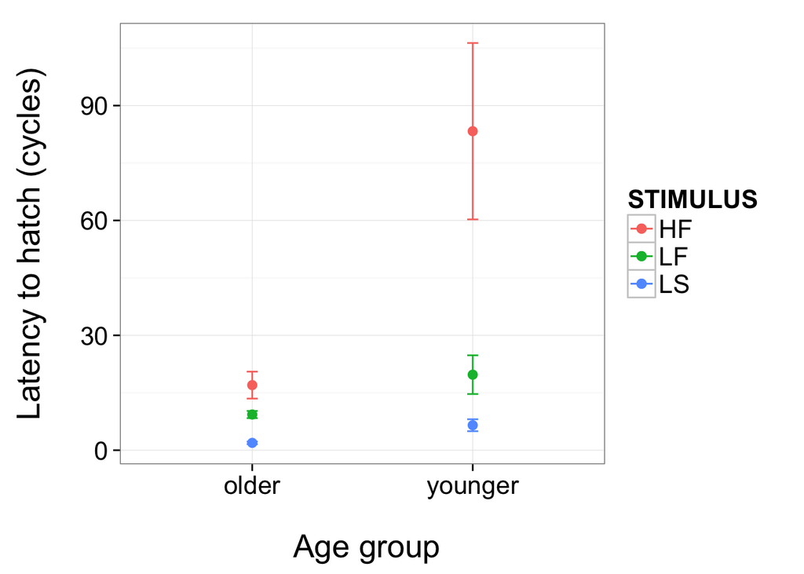

```r
ggplot(data, aes(x=as.factor(AgeGroup), y=FirstHatch.cycles., colour=STIMULUS)) +
  geom_point(data=cycles_younger_errorstats_g8 , size=3) +
  geom_errorbar(data=cycles_younger_errorstats_g8, aes(ymin=FirstHatch.cycles.-se, ymax=FirstHatch.cycles.+se), width=0.05)+
  geom_point(data=cycles_older_errorstats_g8, size=3) +
  geom_errorbar(data=cycles_older_errorstats_g8, aes(ymin=FirstHatch.cycles.-se, ymax=FirstHatch.cycles.+se), width=0.05)+
  theme_bw(20)+
  ylab("Latency to hatch (cycles)\n")+
  xlab("\n Age group")
```

### Discussion

Older embryos showed lower latency to hatch, indicating less cue sampling, and more hatching overall. Their similarly high responses to two of the stimuli suggest they ceased to discriminate using slow-to-assess properties as indicators of safety; however, they showed little hatching if either frequency spectrum or a fast temporal pattern allowed rapid assessment of low risk.

### Conclusion

Developmental changes in behavior due to ontogenetic adaptation of decision processes are likely to be widespread. Vibration-cued hatching allows us to use the power of playback experiments to improve our understanding of the development of adaptive embryo behavior.